# ExAC Conservation Analysis

## Genome Conversion

First, we need to liftover the genome coordinates from hg19 to hg 38. The appropriate chain file is needed to convert between hg38 and hg19, which can be retrieved with `wget http://hgdownload.cse.ucsc.edu/goldenPath/hg19/liftOver/hg19ToHg38.over.chain.gz`.

```r
# write input BED file for liftOver, format, tab-separated: chrN    start   end
write.table(data %>%
                select(chr, start, end, ensembl_id) %>%
                distinct() %>%
                na.omit(),
            file = '../produced_data/liftover_input_region.bed',
            row.names = F, col.names = F, quote = F, sep = '\t')
# write SNP positions, duplicate SNP position so there is a start and end
write.table(data %>%
                mutate(snp_position_end = snp_position + 1) %>%
                select(chr, snp_position, snp_position_end, id) %>%
                na.omit(),
            file = '../produced_data/liftover_input_snp.bed',
            row.names = F, col.names = F, quote = F, sep = '\t')
```

The liftOver executable can be downloaded from UCSC at http://hgdownload.soe.ucsc.edu/admin/exe/macOSX.x86_64/liftOver

```bash
liftOver ../produced_data/liftover_input_region.bed ../../ref/hg19ToHg38.over.chain ../produced_data/converted_region.bed ../produced_data/unlifted_region.bed
liftOver ../produced_data/liftover_input_snp.bed ../../ref/hg19ToHg38.over.chain ../produced_data/converted_snp.bed ../produced_data/unlifted_snp.bed
```

Now, let’s read in the converted coordinates and join them with our data.

```r
data <- data %>%
    left_join(read.table('../produced_data/converted_region.bed', sep = '\t',
                         col.names = c('chr', 'start_hg38', 'end_hg38', 'ensembl_id'))  %>%
                  select(-chr),
              by = 'ensembl_id')
data <- data %>%
    left_join(read.table('../produced_data/converted_snp.bed', sep = '\t',
                         col.names = c('chr', 'snp_position_hg38', 'snp_position_end_hg38', 'id')) %>%
                     select(-chr), by = 'id') %>%
    # change snp position end so that it is the same as snp position
    mutate(snp_position_end_hg38 = snp_position_hg38)
```

## Extract conservation scores

Now that we have converted all of our coordinates, we will look up the conservation for each SNP position.

```r
# output bed file of SNP positions
write.table(file = '../produced_data/snp_positions.bed',
            x = data %>%
                select(chr, snp_position_hg38, snp_position_end_hg38, id) %>%
                na.omit(),
            sep = '\t', col.names = F, row.names = F, quote = F)
```

Before we can use the phastCons wrapper script (that I wrote), we must first sort the bedfile using `bedtools` (installation instructions: http://bedtools.readthedocs.io/en/latest/content/installation.html)

```bash
bedtools sort -i ../produced_data/snp_positions.bed > ../produced_data/snp_positions_sorted.bed
```

Next, we need to download the phastCons files, available in wig format from UCSC. The files can be downloaded with:

```
wget -r ftp://hgdownload.soe.ucsc.edu/goldenPath/hg38/phastCons100way/hg38.100way.phastCons/
```

Now, let’s call the wrapper script, which will take the sorted bed file as input and output the same bed file, with an additional column for the average conservation score for that position. There is an optional argument for the number of processes to use for parallel processing (default is 3). The script takes ~15 minutes to run (time for one chromosome to run) and was run in parallel on the server and will be imported here in the interest of time.

```
# usage: python phastCons_wrapper.py <sorted input bed file> <phastCons folder> <output file name> <num processes>
python ../scripts/phastCons_wrapper.py ../produced_data/snp_positions_sorted.bed ../../ref/phastCons ../produced_data/snp_positions_cons.bed 30
```

```r
cons_scores <- read.table('../produced_data/snp_positions_cons.bed', sep = '\t',
                          col.names = c('chr', 'start', 'end', 'id', 'mean_cons_score'))
# convert NaN to NA
cons_scores[is.na(cons_scores)] <- NA
# some sequences have two variants at the same position. These duplicate positions will have no score because
# we had already iterated through that position. Find these duplicate entries and give them the same conservation
# score as the original entry
cons_scores <- cons_scores %>%
    # combine together to find duplicates
    mutate(position = paste0(chr, start)) %>%
    # get the duplicates which will always have NA score
    filter(duplicated(position)) %>%
    # get the duplicates from the original dataframe, but get the original entry that has the score by
    # using distinct and joining with duplicates with no score
    left_join(mutate(cons_scores, position = paste0(chr, start)) %>%
                  select(position, mean_cons_score) %>%
                  distinct(),
              by = 'position') %>%
    select(-position, -mean_cons_score.x, mean_cons_score = mean_cons_score.y) %>%
    na.omit() %>%
    # combine with original dataframe with duplicates removed
    bind_rows(mutate(cons_scores, position = paste0(chr, start)) %>%
                  filter(!duplicated(position)) %>%
                  select(-position))

data <- left_join(data, select(cons_scores, id, mean_cons_score), by = 'id')
```

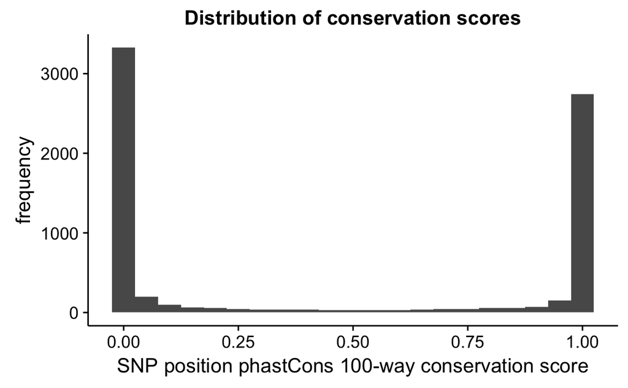

```r
ggplot(data, aes(mean_cons_score)) + geom_histogram(binwidth = 0.05) +
    labs(x = 'SNP position phastCons 100-way conservation score',
         y = 'frequency',
         title = 'Distribution of conservation scores')
```

We now have the conservation score at each SNP position in our library. In order to get a better sense of conservation at each position, we should get a relative position for each mutation and scale it to the range (0, 1) so we can compare mutation positions to each other on the same scale. We will use the intron/exon boundary for each relative position. For SNPs in the exon, we will use whichever intron is closer to the SNP to quantify relative position.